# Regression Analysis

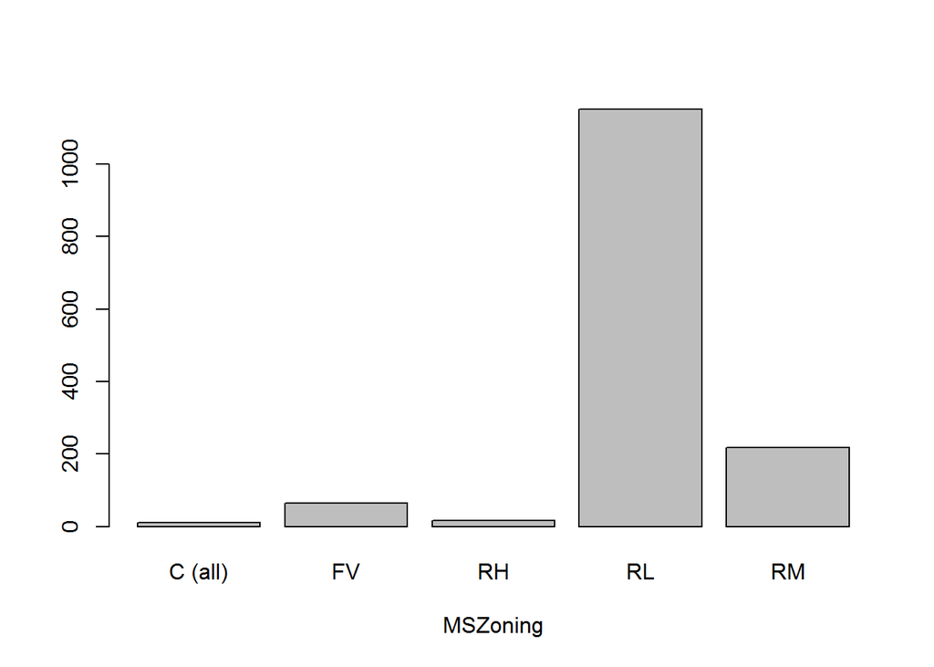

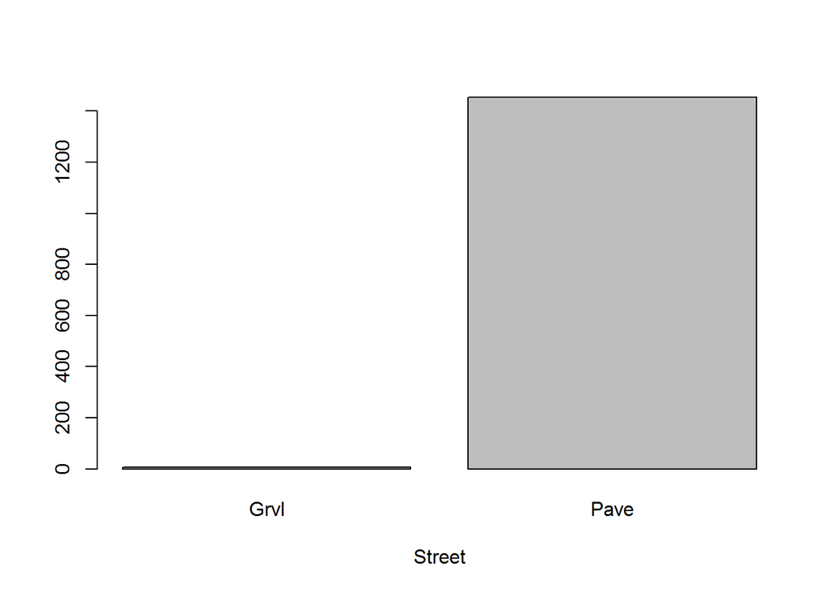

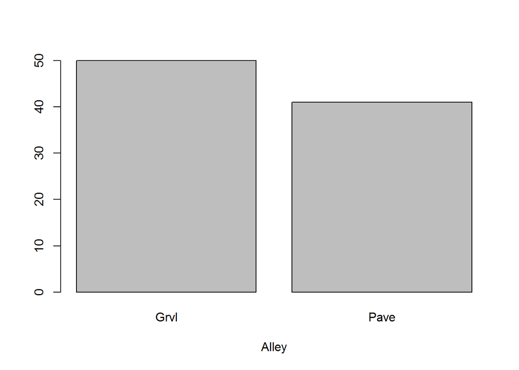

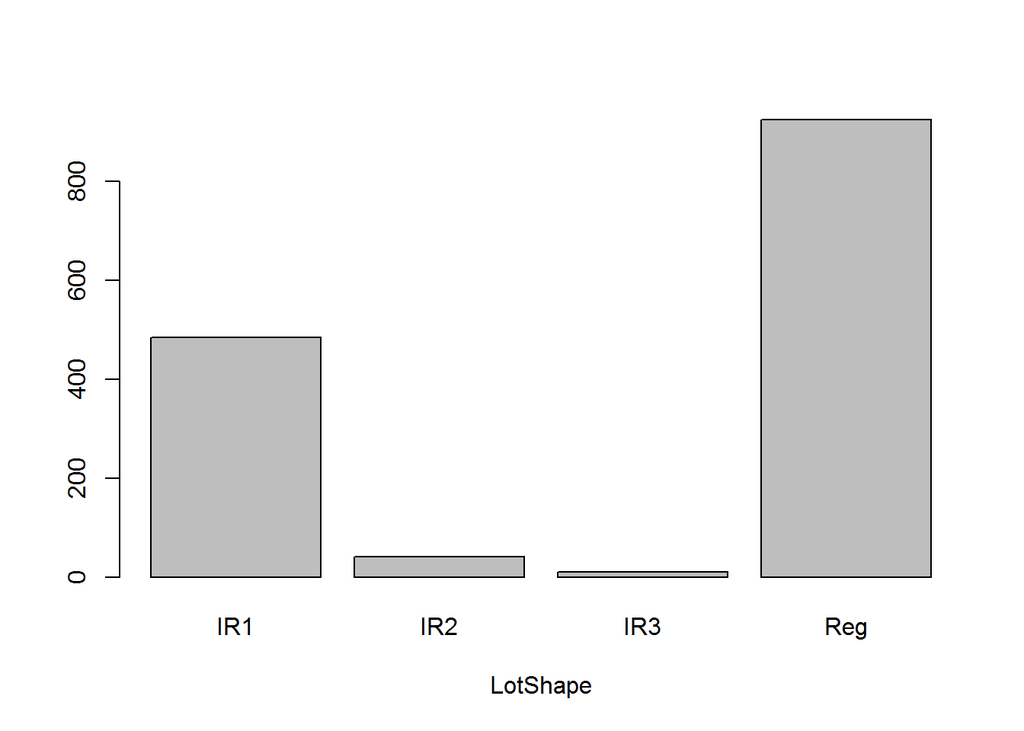

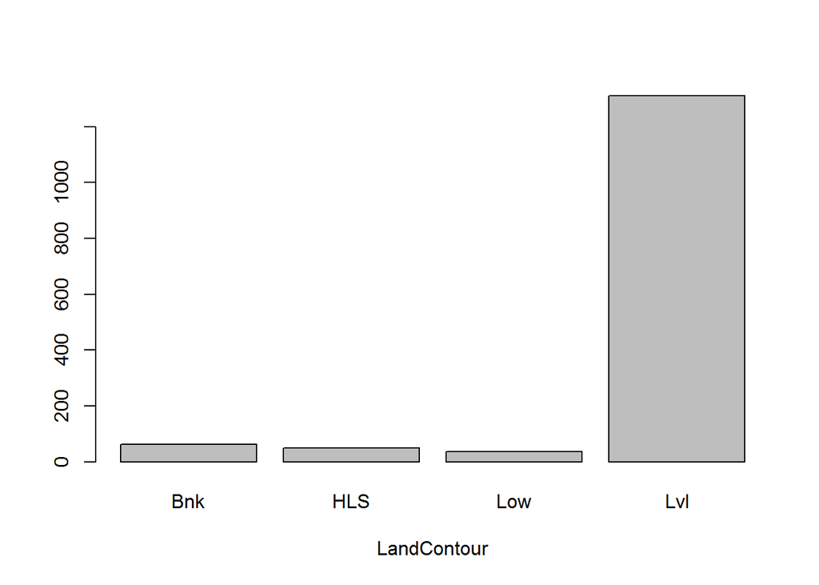

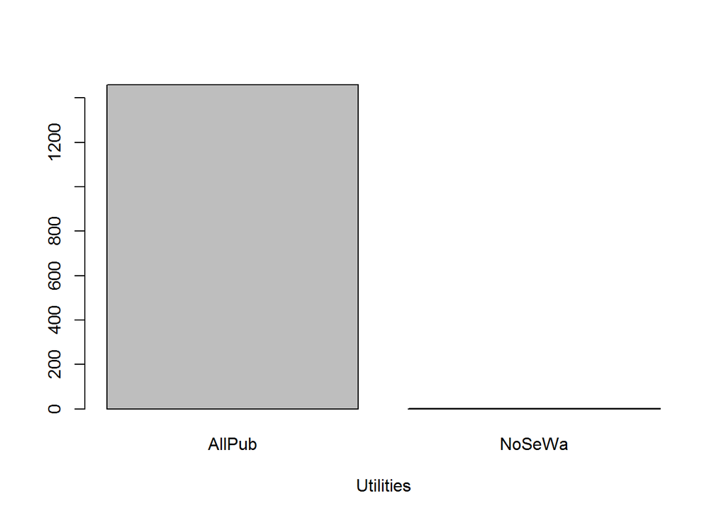

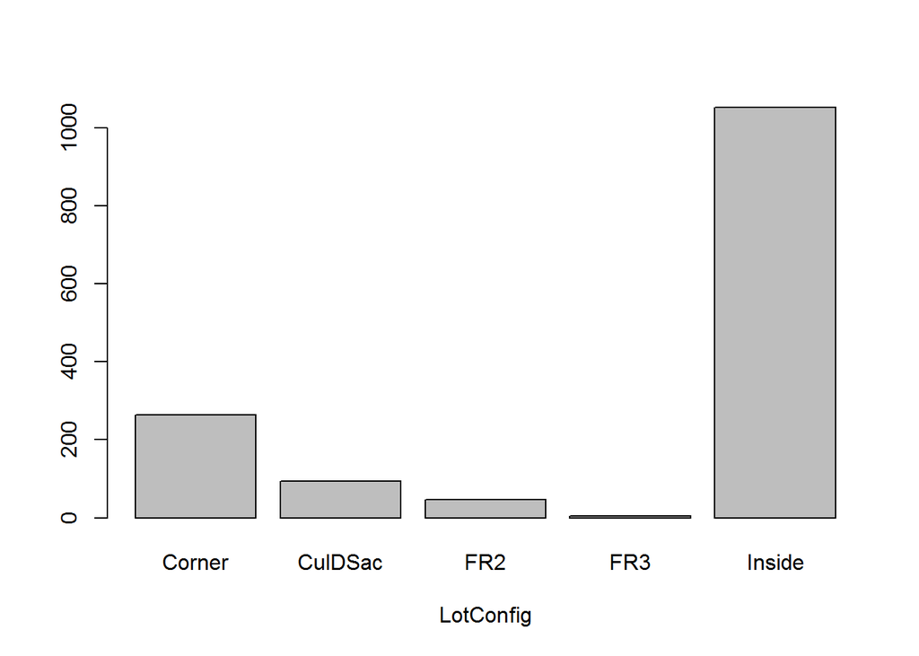

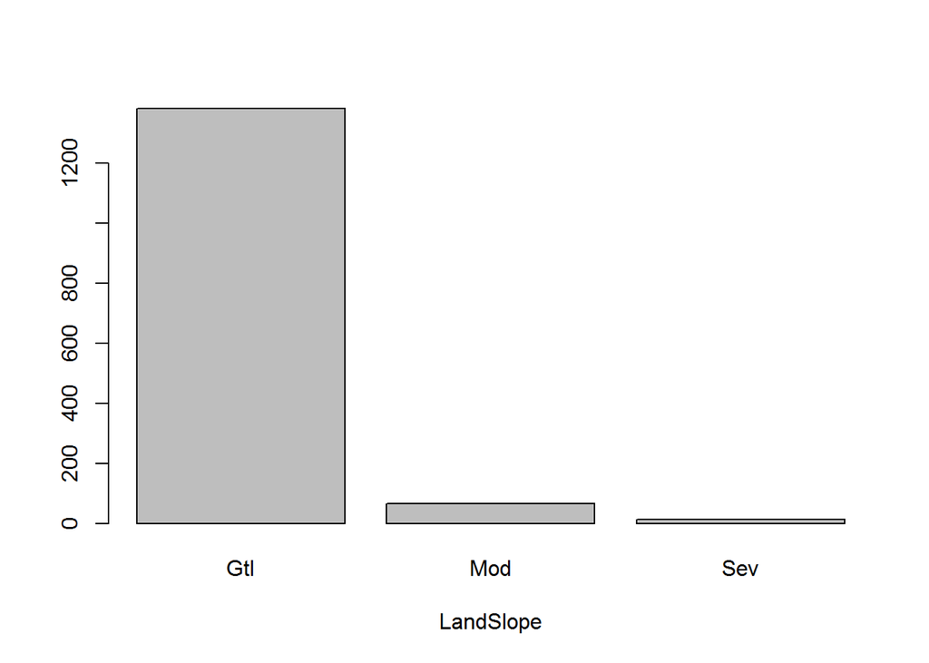

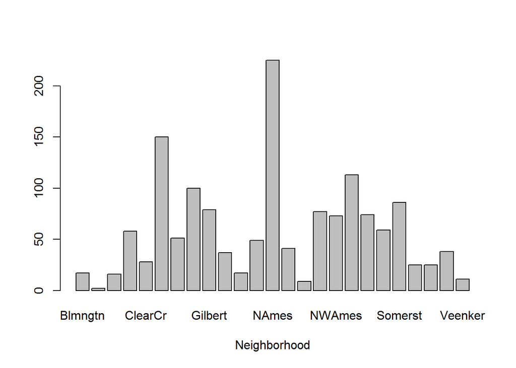

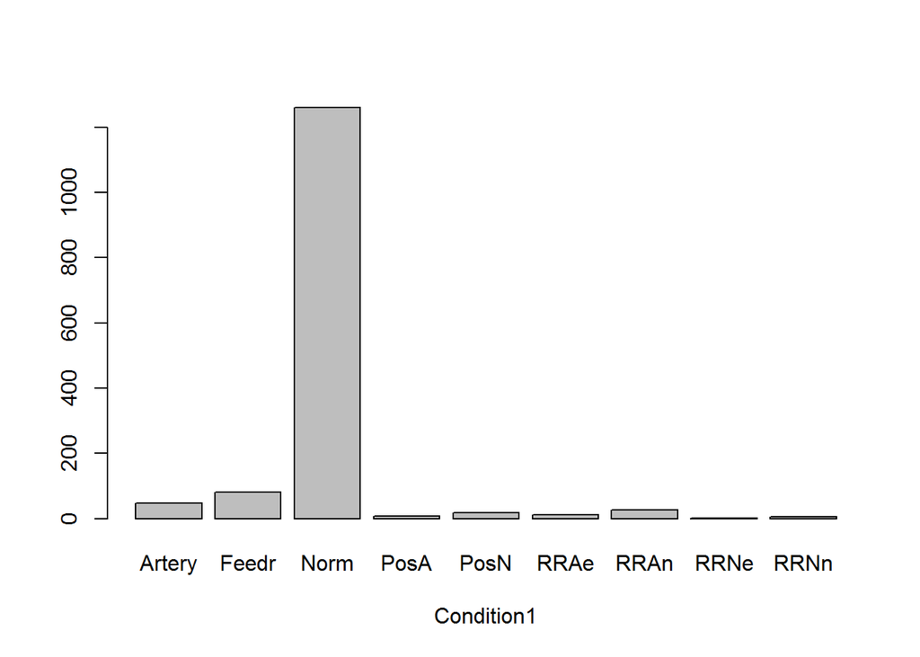

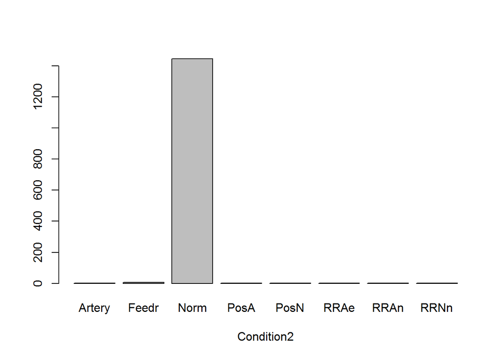

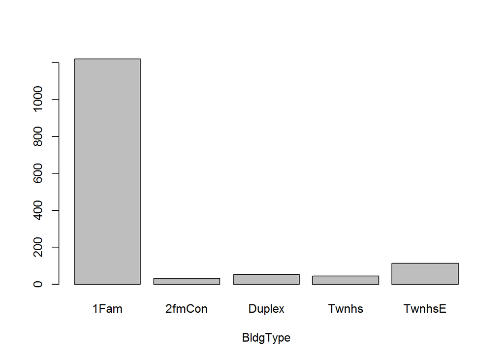

[31 more figures not shown]

```r
for (cols in colnames(fac_dataset_only)){
 barplot(table(fac_dataset_only[[cols]]), xlab = cols)
}
```

```r
# Below Features having no variance or more than 50% missing data can be removed

# Street: Type of road access
# Alley: Type of alley access
# Utilities: Type of utilities available
# LandContour: Flatness of the property
# LandSlope: Slope of property
# Condition1: Proximity to main road or railroad
# Condition2: Proximity to main road or railroad (if a second is present)
# BldgType: Type of dwelling
# RoofMatl: Roof material
# ExterCond: Present condition of the material on the exterior
# BsmtCond: General condition of the basement
# BsmtFinType2: Quality of second finished area (if present)
# Heating: Type of heating
# CentralAir: Central air conditioning
# Electrical: Electrical system
# Functional: Home functionality rating
# GarageQual: Garage quality
# GarageCond: Garage condition
# PavedDrive: Paved driveway
# PoolQC: Pool quality
# Fence: Fence quality
# MiscFeature: Miscellaneous feature not covered in other categories
# SaleType: Type of sale
# SaleCondition: Condition of sale

low_var_fac = c('Street','Alley','Utilities','LandContour','LandSlope','Condition1','Condition2','BldgType','RoofMatl','ExterCond','BsmtCond','BsmtFinType2','Heating','CentralAir','Electrical','Functional','GarageQual','GarageCond','PavedDrive','PoolQC','Fence','MiscFeature','SaleType','SaleCondition')
```

# Bar Plots to find out the relationship between categorical features and target variable i.e. Sale Price

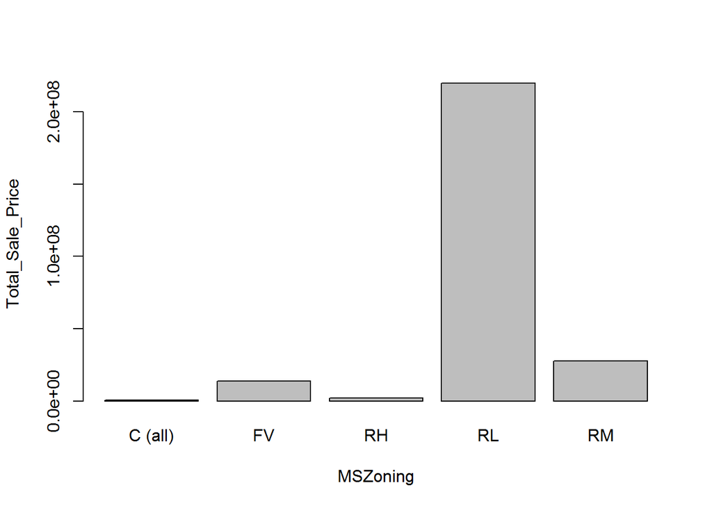

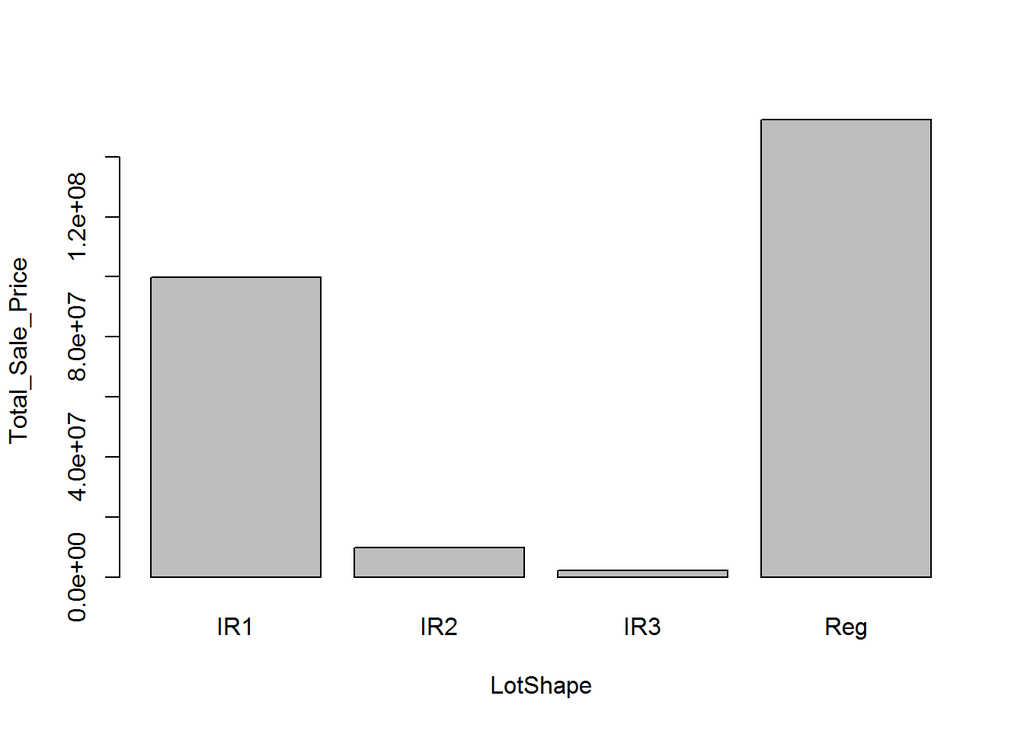

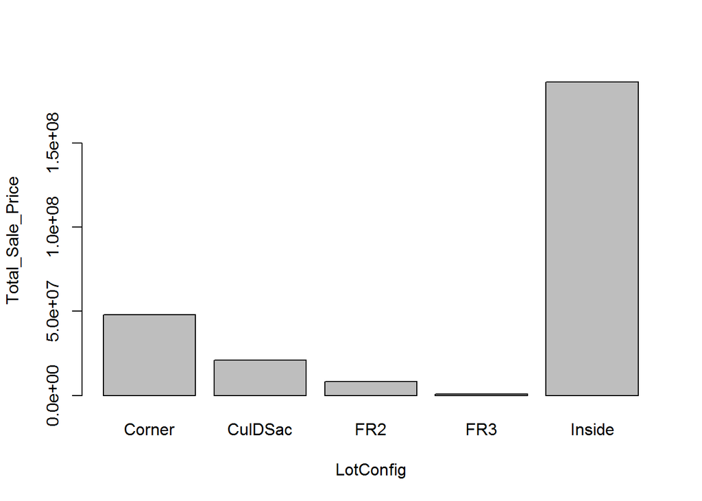

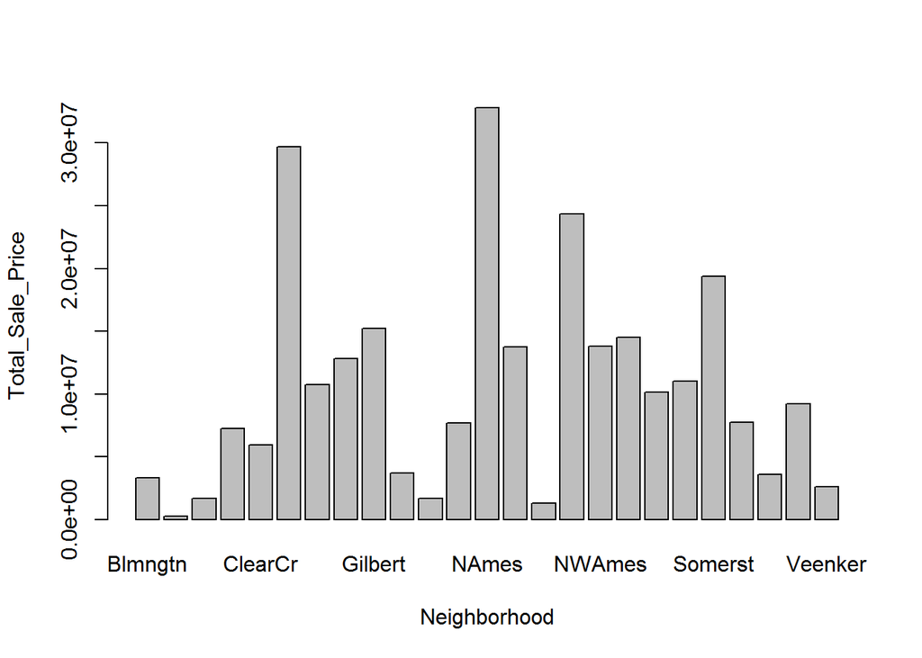

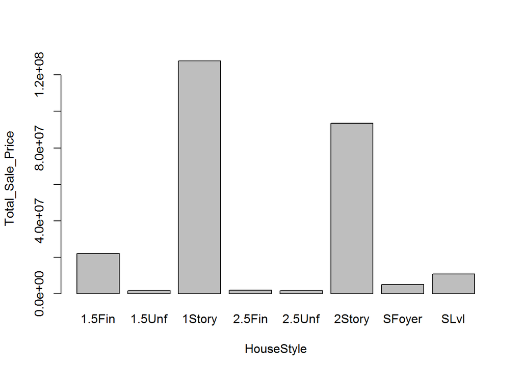

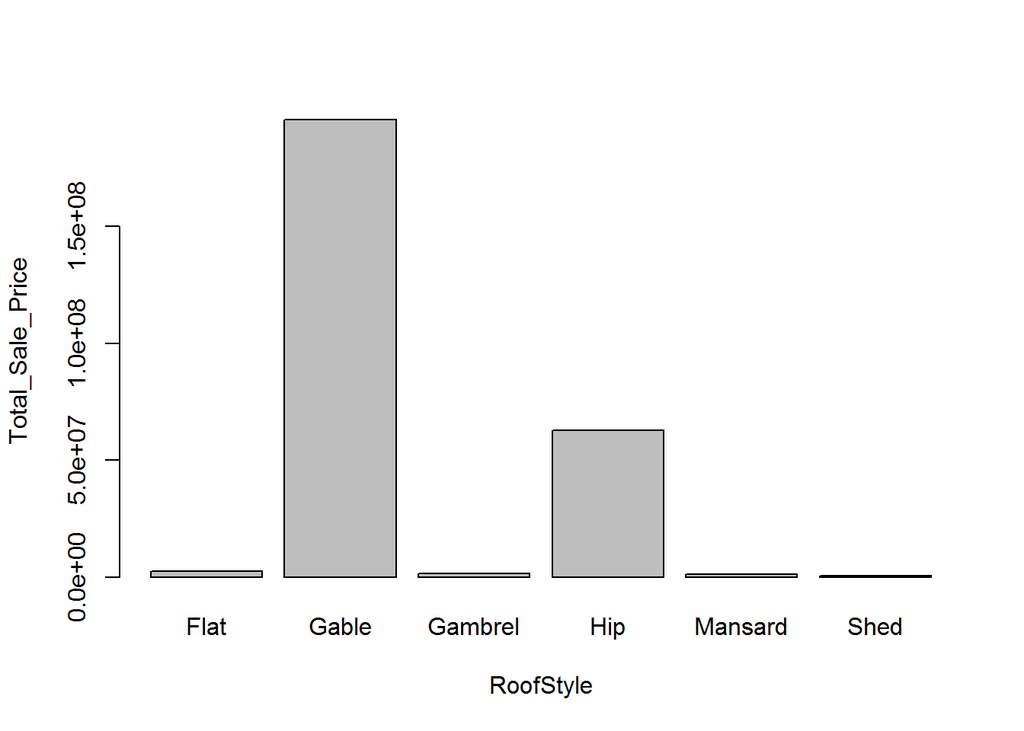

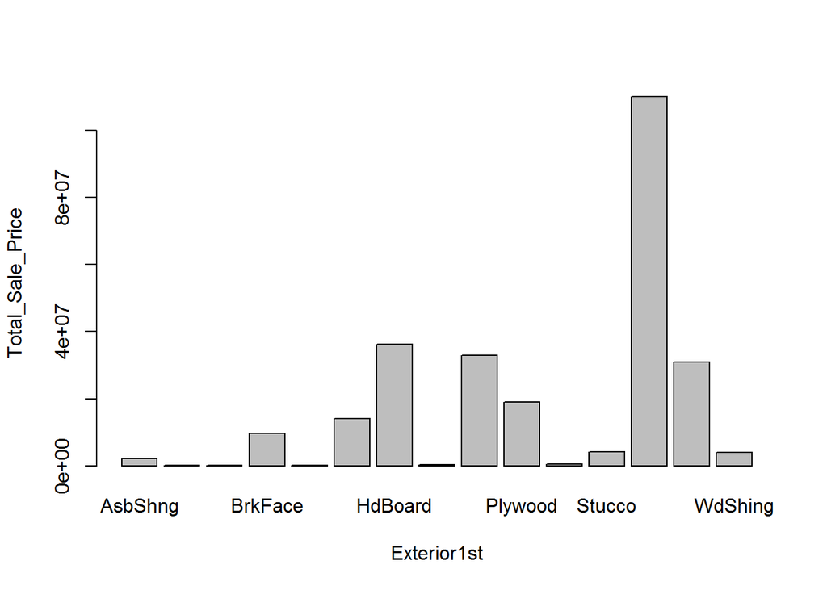

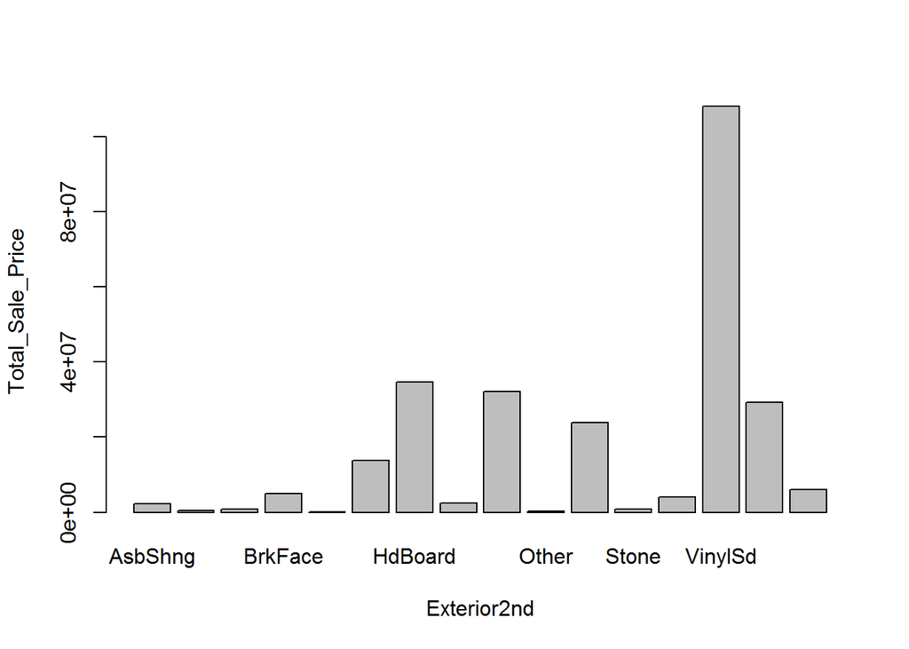

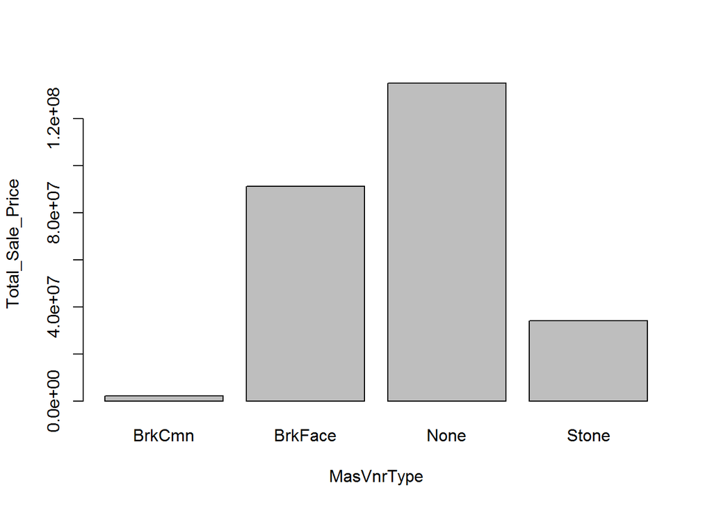

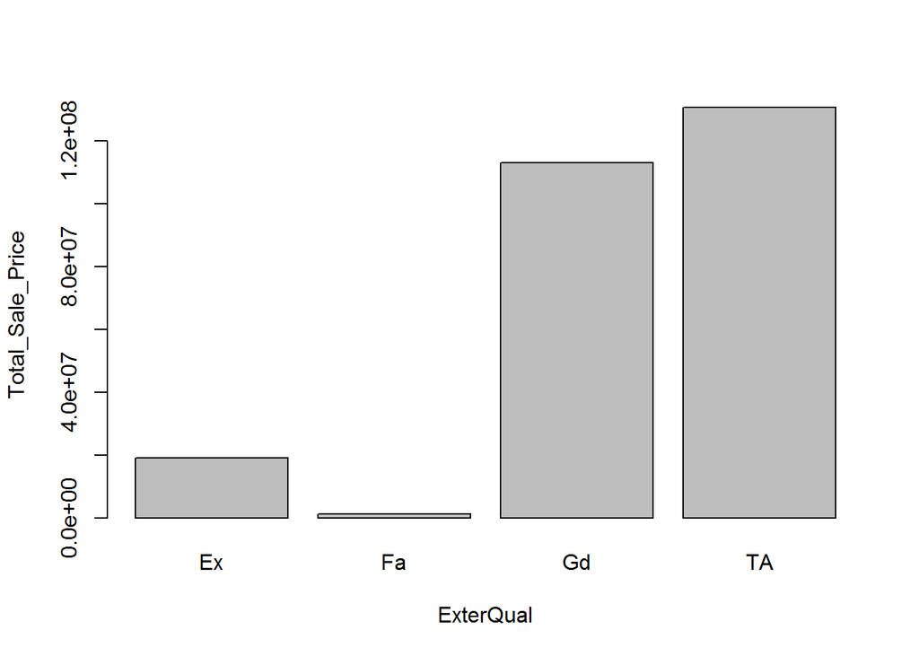

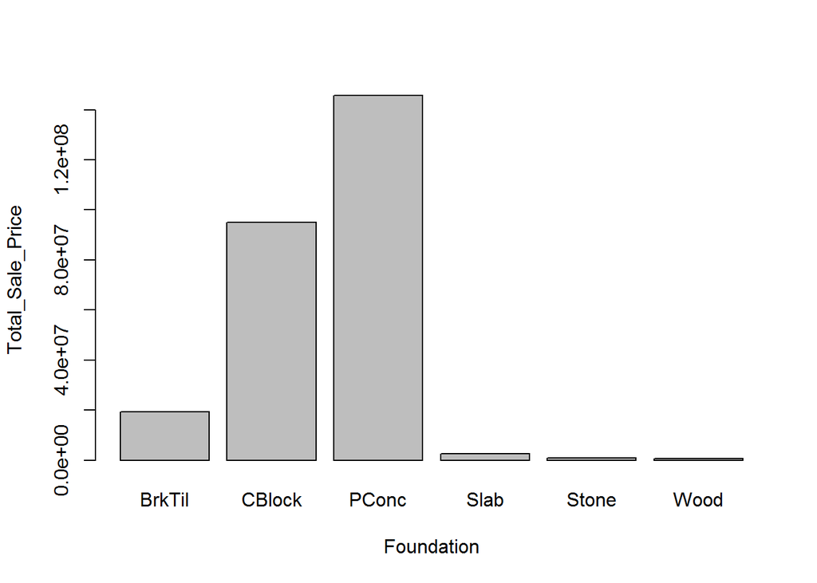

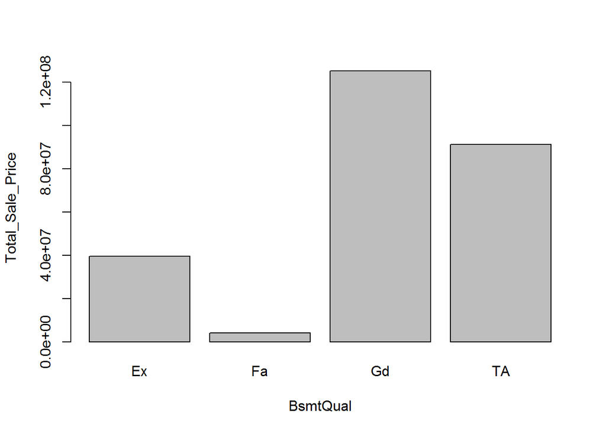

[7 more figures not shown]

```r
for (cols in colnames(fac_dataset)){
  if(cols %in% c(low_var_fac,'SalePrice')){
  }
  else{
  fc_bar_df = data.frame(Sale_Price=fac_dataset$SalePrice,cols = fac_dataset[[cols]])
  fc_bar_df = fc_bar_df %>% group_by(cols) %>% summarise(Total_Sale_Price = sum(Sale_Price))
  barplot(Total_Sale_Price~cols, data = fc_bar_df,xlab = cols)
  }
}
```

```r
# Based on the bar chart following features will be selected

# MSZoning: The general zoning classification
# LotShape: General shape of property
# LotConfig: Lot configuration
# Neighborhood: Physical locations within Ames city limits
# HouseStyle: Style of dwelling
# RoofStyle: Type of roof
# Exterior1st: Exterior covering on house
# Exterior2nd: Exterior covering on house (if more than one material)
# MasVnrType: Masonry veneer type
# ExterQual: Exterior material quality
# Foundation: Type of foundation
# BsmtQual: Height of the basement
# BsmtExposure: Walkout or garden level basement walls
# BsmtFinType1: Quality of basement finished area
# HeatingQC: Heating quality and condition
# KitchenQual: Kitchen quality
# FireplaceQu: Fireplace quality
# GarageType: Garage location
# GarageFinish: Interior finish of the garage

cat_cols_f = c('MSZoning','LotShape','LotConfig','Neighborhood','HouseStyle','RoofStyle','Exterior1st','Exterior2nd','MasVnrType','ExterQual','Foundation','BsmtQual','BsmtExposure','BsmtFinType1','HeatingQC','KitchenQual','FireplaceQu','GarageType','GarageFinish')
```

# Step6: Let’s finalize the list of features/columns that we have seclected after EDA

# Combine test and train data to perform feature engineering and data enginnering steps

```r
final_cols = c(dis_cols_f,cont_cols_f,cat_cols_f,'SalePrice')

#Combine test and train data

combine_dataset = rbind(dataset,dataset_test)


#Select only thsose feature that are selected after EDA

feature_dataset = select(combine_dataset,c("OverallQual","GarageCars","FullBath","GarageYrBlt","TotRmsAbvGrd","YearRemodAdd","Fireplaces","GrLivArea","TotalBsmtSF","GarageArea","X1stFlrSF","BsmtFinSF1","LotFrontage","LotArea","X2ndFlrSF","YearBuilt","MasVnrArea","WoodDeckSF","OpenPorchSF","MSZoning","LotShape","LotConfig","Neighborhood","HouseStyle","RoofStyle","Exterior1st","Exterior2nd","MasVnrType","ExterQual","Foundation","BsmtQual","BsmtExposure","BsmtFinType1","HeatingQC","KitchenQual","FireplaceQu","GarageType","GarageFinish","SalePrice"))

str(feature_dataset)
```

```
## 'data.frame':    2919 obs. of  39 variables:
##  $ OverallQual : int  7 6 7 7 8 5 8 7 7 5 ...
##  $ GarageCars  : int  2 2 2 3 3 2 2 2 2 1 ...
##  $ FullBath    : int  2 2 2 1 2 1 2 2 2 1 ...
##  $ GarageYrBlt : int  2003 1976 2001 1998 2000 1993 2004 1973 1931 1939 ...
##  $ TotRmsAbvGrd: int  8 6 6 7 9 5 7 7 8 5 ...
##  $ YearRemodAdd: int  2003 1976 2002 1970 2000 1995 2005 1973 1950 1950 ...
##  $ Fireplaces  : int  0 1 1 1 1 0 1 2 2 2 ...
##  $ GrLivArea   : int  1710 1262 1786 1717 2198 1362 1694 2090 1774 1077 ...
##  $ TotalBsmtSF : int  856 1262 920 756 1145 796 1686 1107 952 991 ...
##  $ GarageArea  : int  548 460 608 642 836 480 636 484 468 205 ...
##  $ X1stFlrSF   : int  856 1262 920 961 1145 796 1694 1107 1022 1077 ...
##  $ BsmtFinSF1  : int  706 978 486 216 655 732 1369 859 0 851 ...
##  $ LotFrontage : int  65 80 68 60 84 85 75 NA 51 50 ...
##  $ LotArea     : int  8450 9600 11250 9550 14260 14115 10084 10382 6120 7420 ...
```

[output cut: 25 more lines]

# Step 7: Let’s do Feature Engineering

# - club mutiple features into one (if possible) specifically features with year & date

# - Convert categorical variables into discrete ones (if possible)

```r
# Sum of X1stFlrSF and X2ndFlrSF is equal to GrLivArea (We can drop X1stFlrSF and X2ndFlrSF)
feature_dataset_new = subset(feature_dataset,select = -c(X1stFlrSF,X2ndFlrSF))

# Convert ExterQual categorical variable into discrete variable by replacing it with numbers
feature_dataset_new$ExterQual = unclass(feature_dataset$ExterQual)

# Convert BsmtQual categorical variable into discrete variable by replacing it with numbers
feature_dataset_new$BsmtQual = unclass(feature_dataset$BsmtQual)

# Convert BsmtExposure categorical variable into discrete variable by replacing it with numbers
feature_dataset_new$BsmtExposure = unclass(feature_dataset$BsmtExposure)

# Convert HeatingQC categorical variable into discrete variable by replacing it with numbers
feature_dataset_new$HeatingQC = unclass(feature_dataset$HeatingQC)

# Convert KitchenQual categorical variable into discrete variable by replacing it with numbers
feature_dataset_new$KitchenQual = unclass(feature_dataset$KitchenQual)

# Convert FireplaceQu categorical variable into discrete variable by replacing it with numbers
feature_dataset_new$FireplaceQu = unclass(feature_dataset$FireplaceQu)

str(feature_dataset_new)
```

```
## 'data.frame':    2919 obs. of  37 variables:
##  $ OverallQual : int  7 6 7 7 8 5 8 7 7 5 ...
##  $ GarageCars  : int  2 2 2 3 3 2 2 2 2 1 ...
##  $ FullBath    : int  2 2 2 1 2 1 2 2 2 1 ...
##  $ GarageYrBlt : int  2003 1976 2001 1998 2000 1993 2004 1973 1931 1939 ...
##  $ TotRmsAbvGrd: int  8 6 6 7 9 5 7 7 8 5 ...
##  $ YearRemodAdd: int  2003 1976 2002 1970 2000 1995 2005 1973 1950 1950 ...
##  $ Fireplaces  : int  0 1 1 1 1 0 1 2 2 2 ...
##  $ GrLivArea   : int  1710 1262 1786 1717 2198 1362 1694 2090 1774 1077 ...
##  $ TotalBsmtSF : int  856 1262 920 756 1145 796 1686 1107 952 991 ...
##  $ GarageArea  : int  548 460 608 642 836 480 636 484 468 205 ...
##  $ BsmtFinSF1  : int  706 978 486 216 655 732 1369 859 0 851 ...
##  $ LotFrontage : int  65 80 68 60 84 85 75 NA 51 50 ...
##  $ LotArea     : int  8450 9600 11250 9550 14260 14115 10084 10382 6120 7420 ...
##  $ YearBuilt   : int  2003 1976 2001 1915 2000 1993 2004 1973 1931 1939 ...
```

[output cut: 29 more lines]

# Step 8: Data Engineering

# - Data Engineering i.e. Fix/remove missing data, remove outliers/influencers

```r
print(c('Rows before removing Outliers, Columns & Null Values:',dim(feature_dataset_new)[1]))
```

```
## [1] "Rows before removing Outliers, Columns & Null Values:"
## [2] "2919"
```

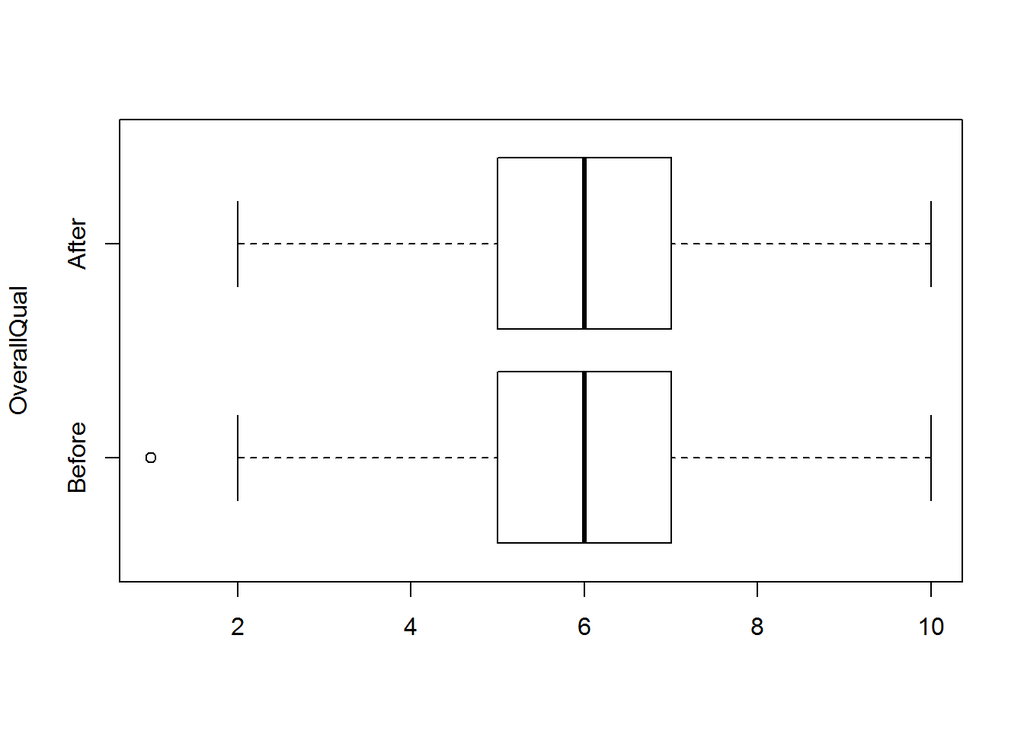

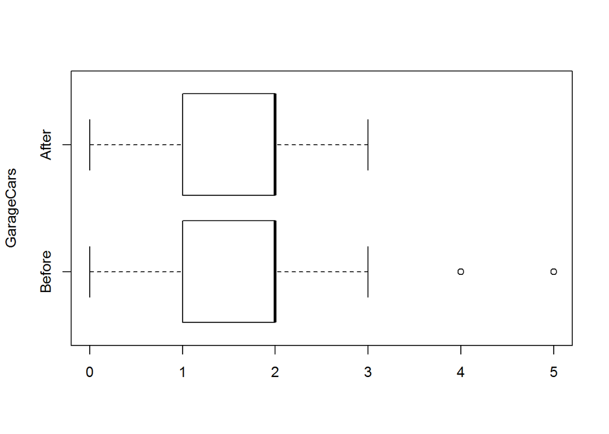

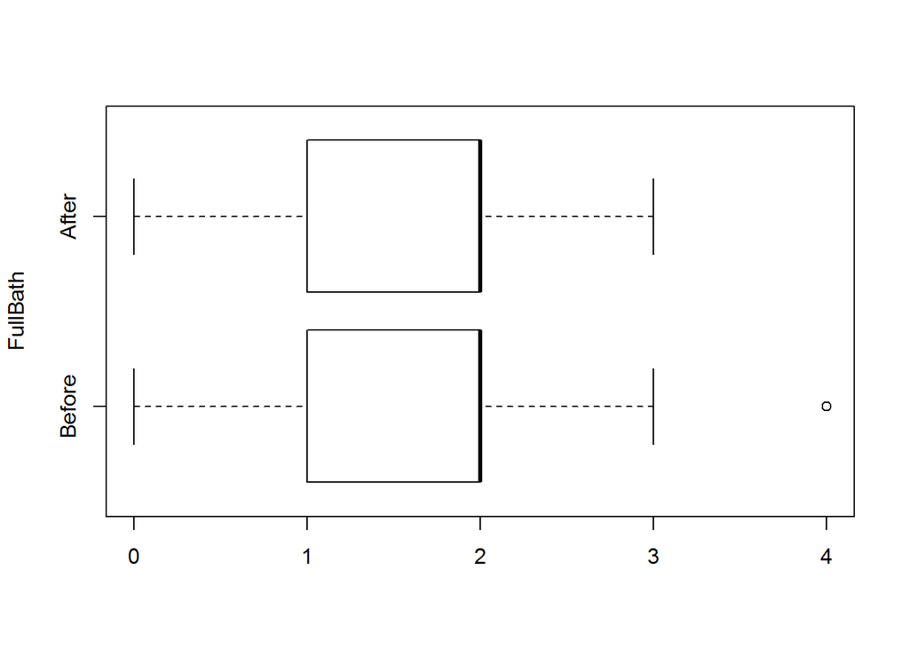

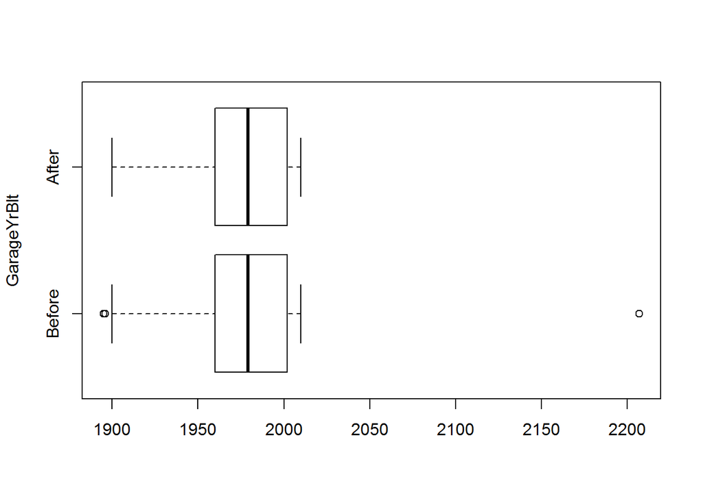

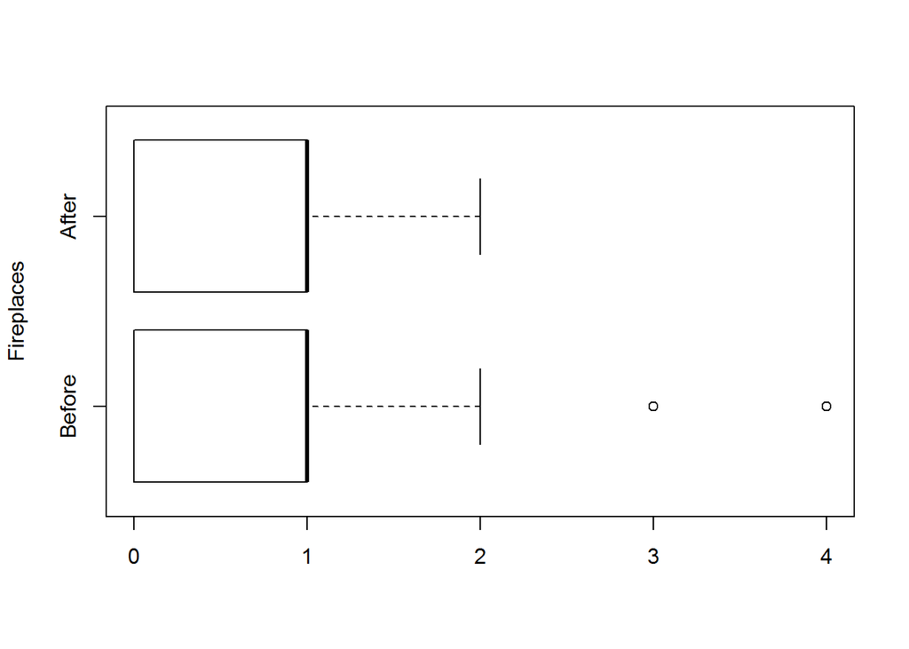

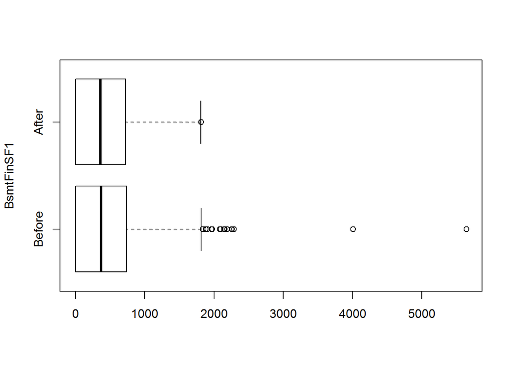

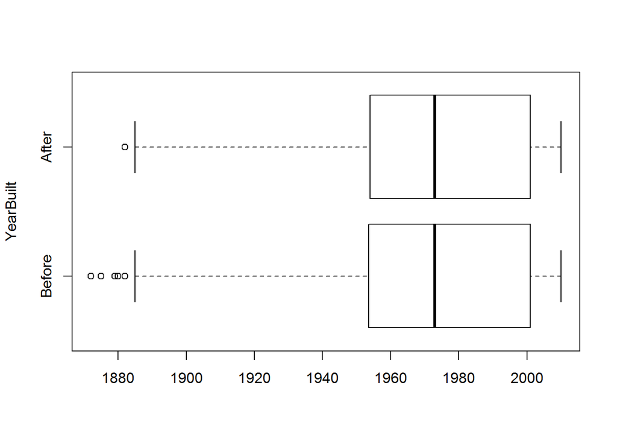

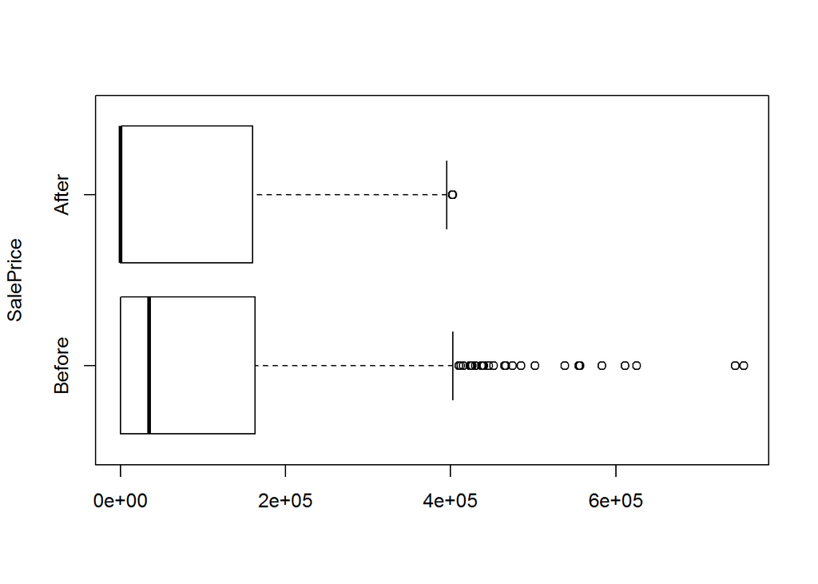

```r
# Look for outliers and remove them from the data

outlier_rmv_dataset = feature_dataset_new

for (cols in colnames(outlier_rmv_dataset)){

  if (!is.factor(outlier_rmv_dataset[[cols]]))
  {
    outliers = sort(boxplot(outlier_rmv_dataset[[cols]],plot = FALSE)$out, decreasing = TRUE)

    if(length(outliers!=0) && length(outliers)<25)
    {
      outlier_rmv_dataset = outlier_rmv_dataset[-which(outlier_rmv_dataset[[cols]] %in% outliers),]
      boxplot(feature_dataset_new[[cols]],outlier_rmv_dataset[[cols]],ylab=cols,names = c('Before','After'),horizontal = TRUE)
    }
  }
}
```

```r
# Let's fix null values issue now. Let's see how many null values are there in our data

# Replace NA values in FireplaceQu with 0
outlier_rmv_dataset$FireplaceQu = ifelse(is.na(outlier_rmv_dataset$FireplaceQu),0,outlier_rmv_dataset$FireplaceQu)

# Drop LotFrontage as there are high number of NULL values
outlier_rmv_dataset = subset(outlier_rmv_dataset,select = -c(LotFrontage))

# Drop rows hahing 1 or 2 missing values
outlier_rmv_dataset = outlier_rmv_dataset[-which(is.na(outlier_rmv_dataset$GarageCars)),]
outlier_rmv_dataset = outlier_rmv_dataset[-which(is.na(outlier_rmv_dataset$KitchenQual)),]
outlier_rmv_dataset = outlier_rmv_dataset[-which(is.na(outlier_rmv_dataset$MSZoning)),]
outlier_rmv_dataset = outlier_rmv_dataset[-which(is.na(outlier_rmv_dataset$Exterior1st)),]
outlier_rmv_dataset = outlier_rmv_dataset[-which(is.na(outlier_rmv_dataset$TotalBsmtSF)),]
outlier_rmv_dataset = outlier_rmv_dataset[-which(is.na(outlier_rmv_dataset$MasVnrArea)),]
outlier_rmv_dataset = outlier_rmv_dataset[-which(is.na(outlier_rmv_dataset$MasVnrType)),]

# Replace NA values in BsmtQual with 0
outlier_rmv_dataset$BsmtQual = ifelse(is.na(outlier_rmv_dataset$BsmtQual),0,outlier_rmv_dataset$BsmtQual)

# Replace NA values in BsmtExposure with 0
outlier_rmv_dataset$BsmtExposure = ifelse(is.na(outlier_rmv_dataset$BsmtExposure),0,outlier_rmv_dataset$BsmtExposure)

# Replace NA values in BsmtFinType1 with 0
outlier_rmv_dataset$BsmtFinType1 = ifelse(is.na(outlier_rmv_dataset$BsmtFinType1),'Missing',outlier_rmv_dataset$BsmtFinType1)

# Replace NA values in GarageType with 0
outlier_rmv_dataset$GarageType = ifelse(is.na(outlier_rmv_dataset$GarageType),'Missing',outlier_rmv_dataset$GarageType)

# Drop rows in GarageYrBlt with missing values
outlier_rmv_dataset = outlier_rmv_dataset[-which(is.na(outlier_rmv_dataset$GarageYrBlt)),]


print(c('Rows after removing Outliers and null values:',dim(outlier_rmv_dataset)[1]))
```

```
## [1] "Rows after removing Outliers and null values:"
## [2] "2659"
```

```r
missing.data.count(outlier_rmv_dataset)
```

```
## [1] "There are No Null Values !! You are all Good"
```

# Step 9:Let’s fix out target variable and check for (Mutivariate Linearity) i.e. linear combination of independent variable also follows a normal distribution that means Y should also follow a normal distribution

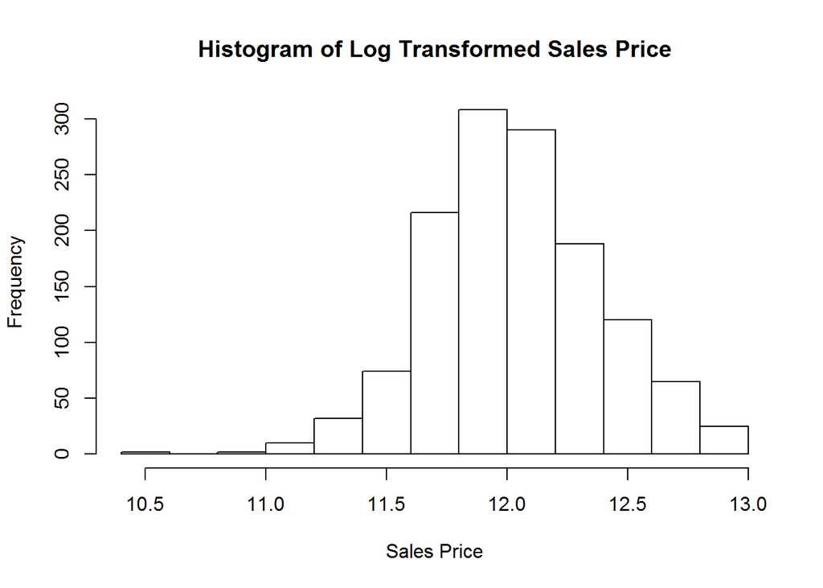

```r
train_dataset = subset(outlier_rmv_dataset,subset = SalePrice>0)
test_dataset = subset(outlier_rmv_dataset,subset = SalePrice==0)
test_dataset = within(test_dataset,rm(SalePrice))

train_dataset$SalePrice = log(train_dataset$SalePrice)

# Visualize the dependent variable and check its skewness abd Kurtosis (After transformation)
hist(train_dataset$SalePrice,main = "Histogram of Log Transformed Sales Price", xlab = "Sales Price")
```

```r
skewness(train_dataset$SalePrice)
```

```
## [1] 0.008999575
```

```r
kurtosis(train_dataset$SalePrice)
```

```
## [1] 0.2302569
```

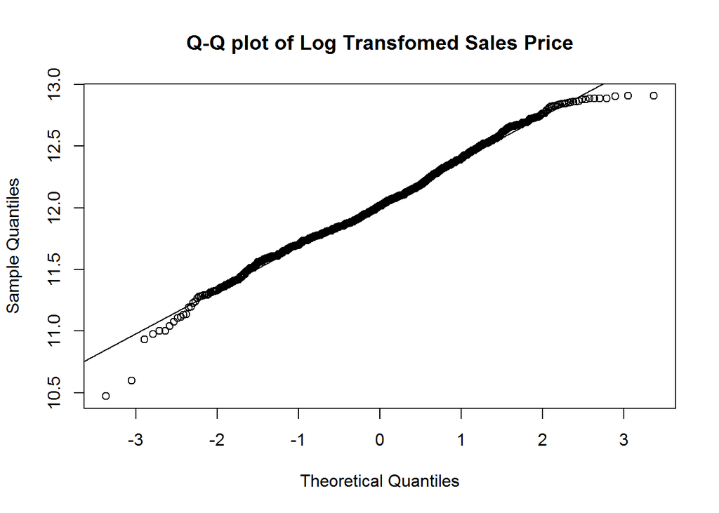

```r
qqnorm(train_dataset$SalePrice,main = "Q-Q plot of Log Transfomed Sales Price")
qqline(train_dataset$SalePrice)
```

# Step 10: Run linear model and consider and look for insignificant coefficients

```r
linear_model = lm(SalePrice~.,train_dataset )
summary(linear_model)
```

```
##
## Call:
## lm(formula = SalePrice ~ ., data = train_dataset)
##
## Residuals:
##      Min       1Q   Median       3Q      Max
## -0.76794 -0.05226  0.00567  0.06282  0.44956
##
## Coefficients: (1 not defined because of singularities)
##                       Estimate Std. Error t value Pr(>|t|)
## (Intercept)          4.693e+00  8.102e-01   5.793 8.80e-09 ***
## OverallQual          5.741e-02  4.888e-03  11.745  < 2e-16 ***
## GarageCars           1.764e-02  1.129e-02   1.562 0.118483
## FullBath            -1.063e-02  9.651e-03  -1.101 0.271106
## GarageYrBlt          3.295e-05  2.811e-04   0.117 0.906691
## TotRmsAbvGrd         5.032e-03  3.988e-03   1.262 0.207319
## YearRemodAdd         1.813e-03  2.389e-04   7.590 6.36e-14 ***
## Fireplaces           2.138e-02  1.081e-02   1.978 0.048106 *
## GrLivArea            2.248e-04  2.062e-05  10.906  < 2e-16 ***
## TotalBsmtSF          7.674e-05  1.888e-05   4.065 5.11e-05 ***
## GarageArea           1.391e-04  3.809e-05   3.652 0.000271 ***
## BsmtFinSF1           7.220e-05  1.308e-05   5.519 4.17e-08 ***
## LotArea              2.363e-06  3.923e-07   6.024 2.26e-09 ***
## YearBuilt            1.063e-03  3.627e-04   2.932 0.003431 **
## MasVnrArea           3.947e-05  2.952e-05   1.337 0.181486
## WoodDeckSF           1.111e-04  2.758e-05   4.027 6.00e-05 ***
## OpenPorchSF          2.258e-04  5.638e-05   4.006 6.56e-05 ***
## MSZoningFV           5.016e-01  5.937e-02   8.449  < 2e-16 ***
## MSZoningRH           4.393e-01  6.104e-02   7.198 1.07e-12 ***
## MSZoningRL           4.964e-01  5.018e-02   9.891  < 2e-16 ***
## MSZoningRM           4.245e-01  4.724e-02   8.986  < 2e-16 ***
## LotShapeIR2          2.205e-02  2.081e-02   1.059 0.289659
## LotShapeIR3         -3.187e-02  4.029e-02  -0.791 0.429058
## LotShapeReg         -4.900e-03  7.878e-03  -0.622 0.534037
## LotConfigCulDSac     2.267e-02  1.534e-02   1.478 0.139661
## LotConfigFR2        -4.465e-02  1.953e-02  -2.286 0.022441 *
## LotConfigFR3        -4.348e-02  5.835e-02  -0.745 0.456371
## LotConfigInside     -6.959e-03  8.459e-03  -0.823 0.410844
## NeighborhoodBlueste  2.804e-03  8.915e-02   0.031 0.974912
## NeighborhoodBrDale  -3.817e-02  5.016e-02  -0.761 0.446802
```

[output cut: 80 more lines]

```
## KitchenQual         -1.591e-02  5.823e-03  -2.733 0.006375 **
## FireplaceQu          1.056e-03  3.273e-03   0.323 0.747053
## GarageType2          1.259e-01  5.512e-02   2.285 0.022508 *
## GarageType3          7.521e-02  6.178e-02   1.217 0.223686
## GarageType4          1.270e-01  5.737e-02   2.214 0.027010 *
## GarageType5          4.085e-02  6.910e-02   0.591 0.554504
## GarageType6          9.408e-02  5.513e-02   1.707 0.088155 .
## GarageFinishRFn     -2.873e-04  9.538e-03  -0.030 0.975973
## GarageFinishUnf     -1.964e-02  1.165e-02  -1.685 0.092192 .
## ---
## Signif. codes:  0 '***' 0.001 '**' 0.01 '*' 0.05 '.' 0.1 ' ' 1
##
## Residual standard error: 0.1117 on 1214 degrees of freedom
## Multiple R-squared:  0.9097, Adjusted R-squared:  0.901
## F-statistic: 104.5 on 117 and 1214 DF,  p-value: < 2.2e-16
```

# Step 11: One by one Remove insignificant parameters and re-run the linear regression model til you get all significant coefficiants

```r
train_dataset1 = within(train_dataset,rm(Exterior1st,RoofStyle,Exterior2nd,LotShape,BsmtFinType1,Foundation,HouseStyle,FireplaceQu,TotRmsAbvGrd,
                                        GarageCars,LotConfig,GarageYrBlt,FullBath,MasVnrArea,ExterQual,GarageFinish,BsmtQual,BsmtExposure,GarageType,
                                        Neighborhood,MasVnrType))
linear_model = lm(SalePrice~.,train_dataset1)
summary(linear_model)
```

```
##
## Call:
## lm(formula = SalePrice ~ ., data = train_dataset1)
##
## Residuals:
##      Min       1Q   Median       3Q      Max
## -0.82010 -0.05953  0.00782  0.07169  0.49117
##
## Coefficients:
##                Estimate Std. Error t value Pr(>|t|)
## (Intercept)   4.596e+00  4.736e-01   9.705  < 2e-16 ***
## OverallQual   7.599e-02  4.494e-03  16.909  < 2e-16 ***
## YearRemodAdd  1.985e-03  2.389e-04   8.307 2.42e-16 ***
## Fireplaces    4.296e-02  6.434e-03   6.676 3.60e-11 ***
## GrLivArea     2.351e-04  1.015e-05  23.158  < 2e-16 ***
## TotalBsmtSF   9.758e-05  1.160e-05   8.410  < 2e-16 ***
## GarageArea    1.556e-04  2.468e-05   6.304 3.95e-10 ***
## BsmtFinSF1    1.040e-04  9.213e-06  11.289  < 2e-16 ***
## LotArea       2.471e-06  3.597e-07   6.870 9.87e-12 ***
## YearBuilt     1.052e-03  1.823e-04   5.772 9.74e-09 ***
## WoodDeckSF    9.706e-05  2.876e-05   3.376 0.000758 ***
## OpenPorchSF   1.980e-04  5.827e-05   3.398 0.000699 ***
## MSZoningFV    4.451e-01  4.796e-02   9.281  < 2e-16 ***
## MSZoningRH    3.571e-01  5.657e-02   6.314 3.72e-10 ***
## MSZoningRL    4.331e-01  4.459e-02   9.714  < 2e-16 ***
## MSZoningRM    3.356e-01  4.503e-02   7.452 1.66e-13 ***
## HeatingQC    -1.262e-02  2.343e-03  -5.389 8.40e-08 ***
## KitchenQual  -2.258e-02  5.575e-03  -4.049 5.44e-05 ***
## ---
## Signif. codes:  0 '***' 0.001 '**' 0.01 '*' 0.05 '.' 0.1 ' ' 1
##
## Residual standard error: 0.1229 on 1314 degrees of freedom
## Multiple R-squared:  0.8817, Adjusted R-squared:  0.8802
## F-statistic: 576.3 on 17 and 1314 DF,  p-value: < 2.2e-16
```

```r
y.hat = fitted(linear_model)
```

# Step 10: Cite and Validate Linear Regression Assumptions

# Mutivariate Linearity (QQ Plot) - For mutiplie linear regression check for (Mutivariate Normality) i.e. linear combination of independent variable also follows a normal distribution that means Y should also follow a normal distribution